# wrangle, check & plot data

29. Oct 2020

## Bevor es losgeht

- Git installiert?
- Account bei Github?

## Agenda

1. Git & Github
2. Piping
3. Transform Data
4. Check Data
5. Plot Data

## Git & Github

## Git

- Versionskontrolle von Dateien
- lokale Installation
- de facto Standard
- Kompatibel zu webhoster wie Github, Gitlab, …

## Github

- hostet Dateien und Versionierung
- je Projekt wird ein “repository” angelegt (1 GB)
- Code, Daten, … als komplettes Projekt teilbar

## Connect: RStudio-Git-Github

### Einmalig (!) je Gerät

Anleitung siehe z.B. [dieser Blogpost](https://www.datasurg.net/2015/07/13/rstudio-and-github/).

1. **In R**
   1. Menü “Tools” **>** “Global Options” **>** “Git/SVN” **>** “Create RSA Key”
   2. Button “View public key” kopieren
2. **Auf github.com**
   1. (rechts oben) auf Profilbild **>** “Settings” **>** “SSH and GPG Keys”
   2. Button “New SSH Key”
   3. public key in Feld “Key” einfügen, Title “RStudio lokale Installation”
3. **In R** in Terminal (nicht Konsole) eingeben:

```bash
git config --global user.email "meine-email@host.de"
git config --global user.name "dein-github-name"
```

## Versionierungsfähiges Projekt

### anlegen

1. **Auf github.com**
   1. neues repository anlegen
   2. im repository: Button “Code” **>** https-Adresse kopieren
2. **In R**
   1. Menü “File” **>** “New Project” **>** “Version Control” **>** “Git”
   2. https-Adresse in “Repository URL” einfügen
   3. Loslegen wie der Wirbelwind

## Versionierungsfähiges Projekt

### pull, commit, push

Empfohlener workflow:

1. “pull” nach jedem Start von RStudio
2. “commit” mit aussagekräftigen “commit messages”  
   unterschiedliche messages für Dateien(gruppen) möglich
3. “push” am Ende einer längeren Bearbeitung (z.B. Tagesende)

## Piping: %>%

## Piping

### das Problem

**Verknüpfung von Funktionen**

Einzelne Schritte

```r
mydata <- import("https://shiny.jschn.org/www/fueleconomy.csv")  # import aus {rio}
mean(mydata$hwy)
```

Verschachtelt

```r
mean(import("https://shiny.jschn.org/www/fueleconomy.csv")$hwy)
```

## Piping

### eine Lösung

**Verknüpfung von Funktionen**

Einzelne Schritte

```r
mydata <- import("https://shiny.jschn.org/www/fueleconomy.csv")  # import aus {rio}
mean(mydata$hwy)
```

Verschachtelt

```r
mean(import("https://shiny.jschn.org/www/fueleconomy.csv")$hwy)
```

Piping

```r
import("https://shiny.jschn.org/www/fueleconomy.csv") %>%
  summarize(mean_hwy = mean(hwy))
```

## Transform Data

## Transform Data

### summarize( ) & mutate( )

```r
mydata <- mydata %>%
  mutate(newVariable_mean1 = (oldVariable1 + oldVariable2)/2,                  # new variable: MW selbst berechnen
         newVariable_mean2 = rowMeans(data.frame(oldVariable1, oldVariable2),  # new variable: MW automatisch
                                      na.rm=TRUE),                             #         Fehlenden Werte entfernen
         newVariable_sum = oldVariable1 + oldVariable2                         # new variable: Summe
         ) %>%
  summarize(mean_of_mean = mean(newVariable_mean1),                            # MW über Spalte newVariable_mean
            sd_of_mean   = sd(newVariable_mean1))                              # SD über Spalte newVariable_mean
```

## Transform Data

### combine tables: bind_cols( ) oder left_join( )

Angenommen wir haben zwei Datensätze derselben Personen (z.B. zu unterschiedlichen Zeiptunkten erhoben)

```r
data1 <- data.frame(id = c(1, 2, 3, 4),
                    var1 = c(3, 6, 2, 5))
data1
```

```
##   id var1
## 1  1    3
## 2  2    6
## 3  3    2
## 4  4    5
```

## Transform Data

### combine tables: bind_cols( ) oder left_join( )

Angenommen wir haben zwei Datensätze derselben Personen (z.B. zu unterschiedlichen Zeiptunkten erhoben)

```r
data1 <- data.frame(id = c(1, 2, 3, 4),
                    var1 = c(3, 6, 2, 5))
data1
```

```
##   id var1
## 1  1    3
## 2  2    6
## 3  3    2
## 4  4    5
```

```r
data2 <- data.frame(id = c(2,1,3,4),
                    var2 = c("B","A","C","D"))
data2
```

```
##   id var2
## 1  2    B
## 2  1    A
## 3  3    C
## 4  4    D
```

## Transform Data

### combine tables: bind_cols( ) oder left_join( )

Angenommen wir haben zwei Datensätze derselben Personen (z.B. zu unterschiedlichen Zeiptunkten erhoben)

```r
data1 <- data.frame(id = c(1, 2, 3, 4),
                    var1 = c(3, 6, 2, 5))
data1
```

```
##   id var1
## 1  1    3
## 2  2    6
## 3  3    2
## 4  4    5
```

```r
data2 <- data.frame(id = c(2,1,3,4),
                    var2 = c("B","A","C","D"))
data2
```

```
##   id var2
## 1  2    B
## 2  1    A
## 3  3    C
## 4  4    D
```

```r
bind_cols(data1, data2)
```

```
##   id var1 id1 var2
## 1  1    3   2    B
## 2  2    6   1    A
## 3  3    2   3    C
## 4  4    5   4    D
```

## Transform Data

### combine tables: bind_cols( ) oder left_join( )

Angenommen wir haben zwei Datensätze derselben Personen (z.B. zu unterschiedlichen Zeiptunkten erhoben)

```r
data1 <- data.frame(id = c(1, 2, 3, 4),
                    var1 = c(3, 6, 2, 5))
data1
```

```
##   id var1
## 1  1    3
## 2  2    6
## 3  3    2
## 4  4    5
```

```r
data2 <- data.frame(id = c(2,1,3,4),
                    var2 = c("B","A","C","D"))
data2
```

```
##   id var2
## 1  2    B
## 2  1    A
## 3  3    C
## 4  4    D
```

```r
bind_cols(data1, data2)
```

```
##   id var1 id1 var2
## 1  1    3   2    B
## 2  2    6   1    A
## 3  3    2   3    C
## 4  4    5   4    D
```

```r
left_join(data1, data2, by="id")
```

```
##   id var1 var2
## 1  1    3    A
## 2  2    6    B
## 3  3    2    C
## 4  4    5    D
```

## Transform Data

### gruppenspezifische Werte

**Aufgabe 1 (bitte piping verwenden):**

1. Erstellt eine neue Variable, die den Benzinverbrauch der Autos über Highway und Stadt mittelt
2. Berechnet *je Hersteller* hier den mittleren Verbrauch  
   hierzu müsst ihr vor `summarize()` eine Gruppierung anhand `group_by()` vornehmen
3. Speichert dieses Ergebnis in einem neuen Objekt

Was bilden die Werte des neuen Objekts ab?

Cheatsheet [data-transformation](https://raw.githubusercontent.com/rstudio/cheatsheets/master/data-transformation.pdf)

## Transform Data

### gruppenspezifische Werte

**Aufgabe 2:**

1. Fügt das neue Objekt an den “alten” Datensatz anhand von `join_left()` an
2. Werft einen Blick in die nun gejointen Daten

Wie wurde das Objekt aus Aufgabe 1 angefügt?  
Wozu bzw. warum könnte das Vorgehen aus Aufgabe 1 und 2 auch mit Daten aus Unterrichtsforschung verwendet werden?

**Aufgabe 3:**  
*Commit* und *Push* auf Github.

## Transform Data

### left_join( ), right_join( ), full_join( ), inner_join( )

Untersuche anhand dieser beiden Minimalbeispiel-Datensätze, zu welchen unterschiedlichen Ergebnissen die Funktionen `left_join()`, `right_join()`, `full_join()`, `inner_join()` kommen

```r
minidata1 <- data.frame(name = c("Aiyse", "Berta", "Carolin"),
                        punkte = c(22, 32, 12))

minidata2 <- data.frame(name = c("Aiyse", "Berta", "Doris"),
                        lernzeit = c(2, 12, 6))
```

(einfach den obigen code herauskopieren)

## Transform Data

### pivot_longer( ), pivot_wider( )

wide datensatz

| person_id | measure_T1 | measure_T2 |
| --- | --- | --- |
| 1 | 2 | 4 |
| 2 | 4 | 6 |
| 3 | 1 | 4 |
| 4 | 2 | 3 |
| 5 | 5 | 6 |

long datensatz

| person_id | pre_post | measure |
| --- | --- | --- |
| 1 | pre | 2 |
| 1 | post | 4 |
| 2 | pre | 4 |
| 2 | post | 6 |
| 3 | pre | 1 |
| 3 | post | 4 |

## Transform Data

### pivot_longer( ), pivot_wider( )

```r
long_df <- wide_df %>%                              # speichere alles folgende in einem neuen Objekt
  pivot_longer(cols = 2:3,                          # welche Variablen sollen transformiert werden?
               names_to = "pre_post",               # Variablennamen kommen in die Spalte mit dem Namen...
               values_to = "measure") %>%           # Werte kommen in die Spalte mit dem Namen...
  mutate(pre_post = ifelse(pre_post == "measure_T1", "pre", "post")) # umcodierung der Variable pre_post

long_df
```

```
## # A tibble: 10 x 3
##    person_id pre_post measure
##        <int> <chr>      <dbl>
##  1         1 pre            2
##  2         1 post           4
##  3         2 pre            4
##  4         2 post           6
##  5         3 pre            1
##  6         3 post           4
##  7         4 pre            2
##  8         4 post           3
##  9         5 pre            5
## 10         5 post           6
```

## Transform Data

### pivot_longer( ), pivot_wider( )

```r
wide_df <- long_df %>%
  mutate(pre_post = ifelse(pre_post == "pre", "measure_T1", "measure_T2")) %>% # umcodierung variable
  pivot_wider(id_cols = person_id,                      # welche Spalte (ID) identifiziert die Zeilen
              names_from = "pre_post",           # nehme die späteren Variablennamen aus der Spalte...
              values_from = "measure")           # nehme die Werte aus der Spalte...

wide_df
```

```
## # A tibble: 5 x 3
##   person_id measure_T1 measure_T2
##       <int>      <dbl>      <dbl>
## 1         1          2          4
## 2         2          4          6
## 3         3          1          4
## 4         4          2          3
## 5         5          5          6
```

## Check Data

## Check Data

### missing data

```r
glimpse(airquality)
```

```
## Rows: 153
## Columns: 6
## $ Ozone   <int> 41, 36, 12, 18, NA, 28, 23, 19, 8, NA, 7, 16, 11, 14, 18, 14,…
## $ Solar.R <int> 190, 118, 149, 313, NA, NA, 299, 99, 19, 194, NA, 256, 290, 2…
## $ Wind    <dbl> 7.4, 8.0, 12.6, 11.5, 14.3, 14.9, 8.6, 13.8, 20.1, 8.6, 6.9, …
## $ Temp    <int> 67, 72, 74, 62, 56, 66, 65, 59, 61, 69, 74, 69, 66, 68, 58, 6…
## $ Month   <int> 5, 5, 5, 5, 5, 5, 5, 5, 5, 5, 5, 5, 5, 5, 5, 5, 5, 5, 5, 5, 5…
## $ Day     <int> 1, 2, 3, 4, 5, 6, 7, 8, 9, 10, 11, 12, 13, 14, 15, 16, 17, 18…
```

## Check Data

### missing data

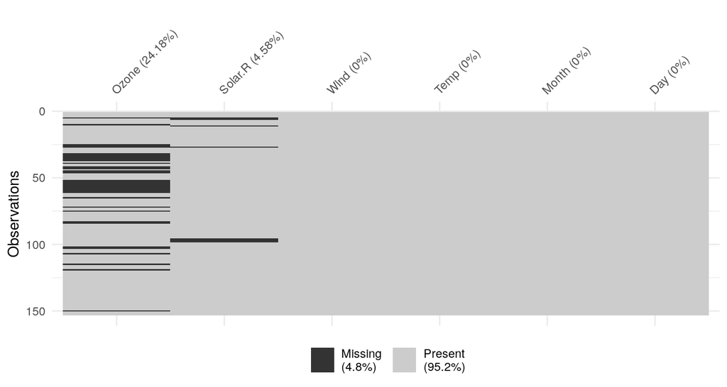

```r
library(naniar)
vis_miss(airquality)
```

## Check Data

### missing data

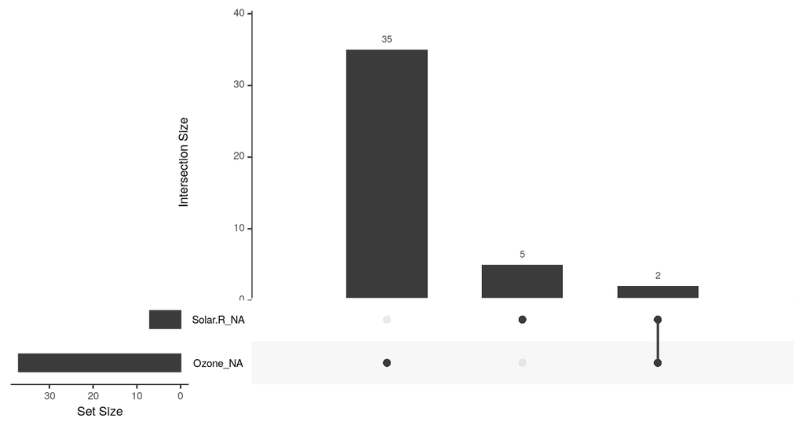

```r
gg_miss_upset(airquality)
```

## Check Data

### missing data

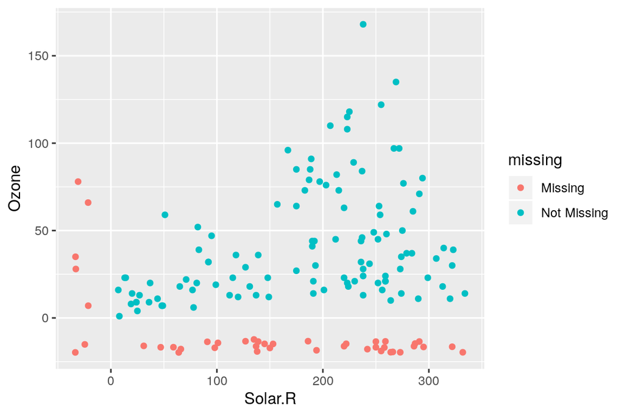

```r
ggplot(airquality, aes(x = Solar.R, y = Ozone)) +
  geom_miss_point()
```

## Plot Data

## Plot Data

### {ggplot2}

- extrem beliebtes Paket für Grafiken
- Teil der `library(tidyverse)`
- benötigt 3 Informationen
  - data
  - mapping `aes()`
  - geoms
- Layer-Aufbau mit `+` verknüpfen

## Plot Data

### {ggplot2}

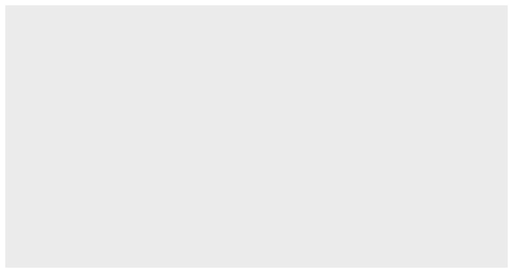

```r
ggplot(data = iris)
```

## Plot Data

### {ggplot2}

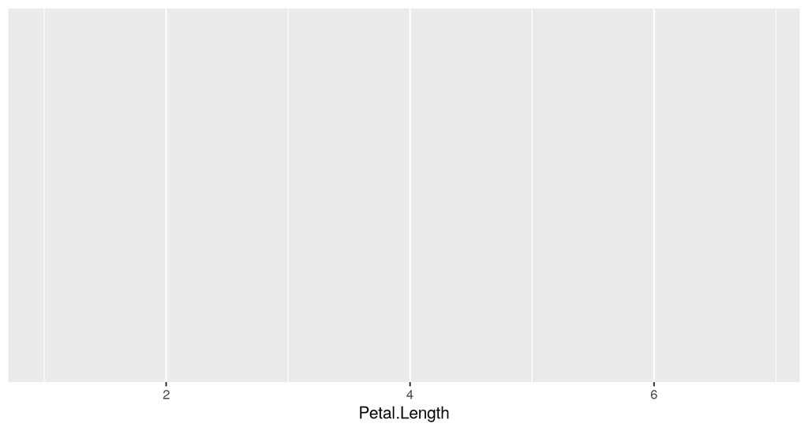

```r
ggplot(data = iris, mapping = aes(x=Petal.Length, fill=Species))
```

## Plot Data

### {ggplot2}

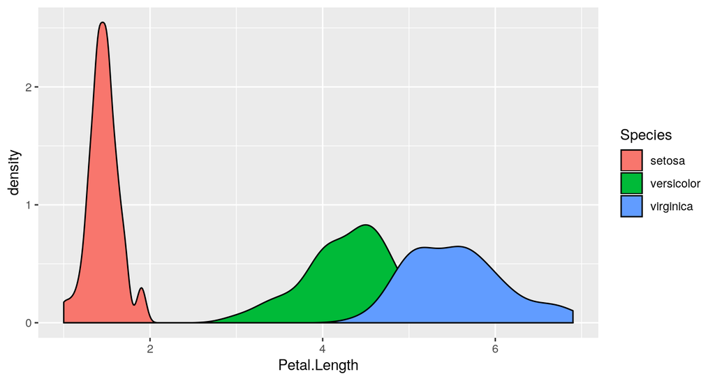

```r
ggplot(data = iris, mapping = aes(x=Petal.Length, fill=Species)) +
  geom_density()
```

## Plot Data

### {ggplot2}

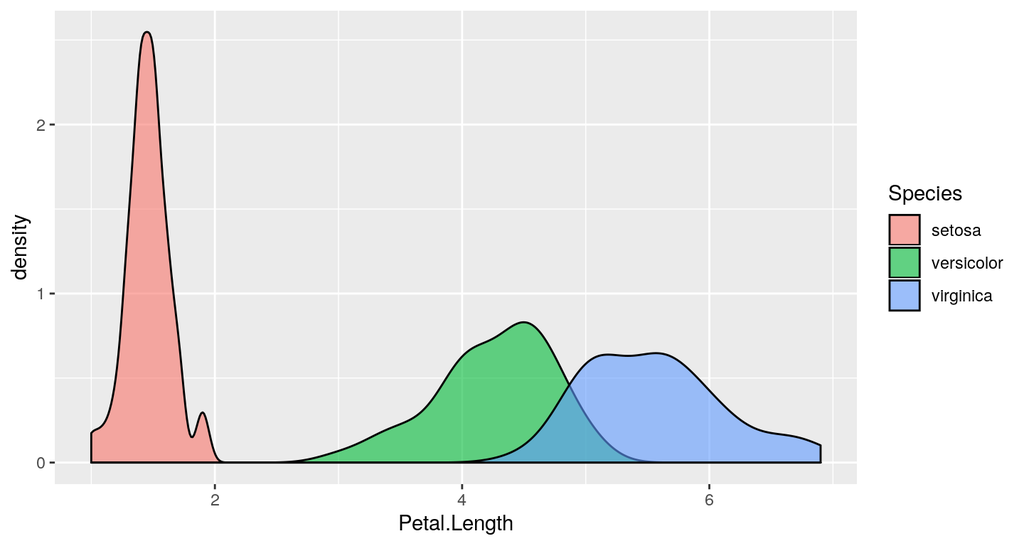

```r
ggplot(data = iris, mapping = aes(x=Petal.Length, fill=Species)) +
  geom_density(alpha = .6)
```

## Plot Data

### {ggplot2}

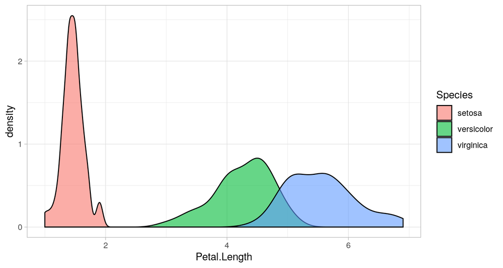

```r
ggplot(data = iris, mapping = aes(x=Petal.Length, fill=Species)) +
  geom_density(alpha = .6) +
  theme_light()
```

## Plot Data

### {ggplot2}

**eigene Exploration**

Datensätze:

- `?mpg`
- `?iris`
- `?sleep`
- `?mtcars`
- `?airquality`

[gutes Cheatsheet](https://github.com/rstudio/cheatsheets/blob/master/data-visualization-2.1.pdf)

- Probiert unterschiedliche Darstellungen aus, keine falsche Scheu
- Code speichern, Plots im Plenum vorstellen

## Plot Data

### unkreativ?

Zusätzliche geoms in Paket **{ggridges}**

data: airquality

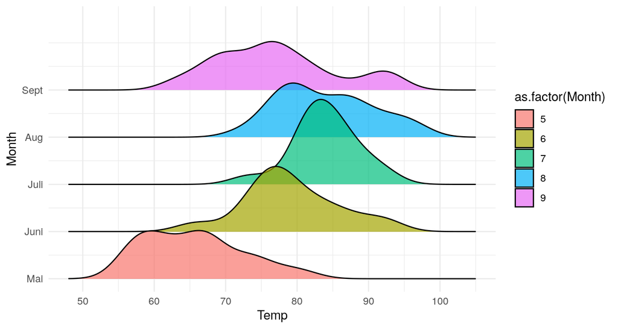

## Plot Data

### unkreativ?

data: iris  
Zusätzliche Transformation vor Plotting: Größe der Punkte basiert auf Mittelwert der Petal.Width und Sepal.Width

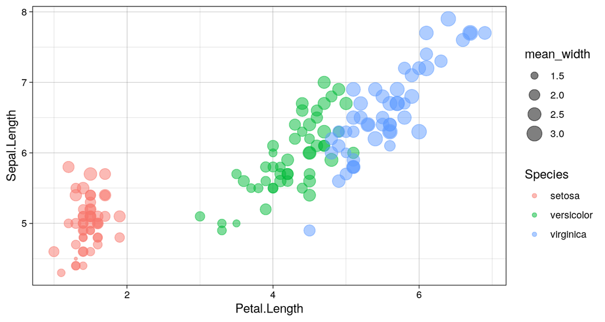

## Plot Data

### unkreativ?

data: sleep

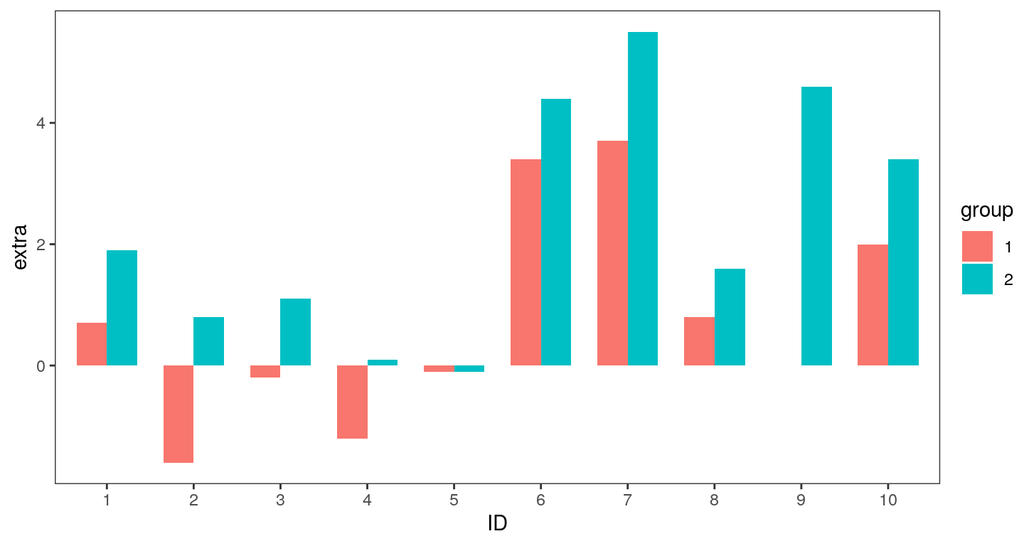

## Plot Data

### unkreativ?

data: beaver1

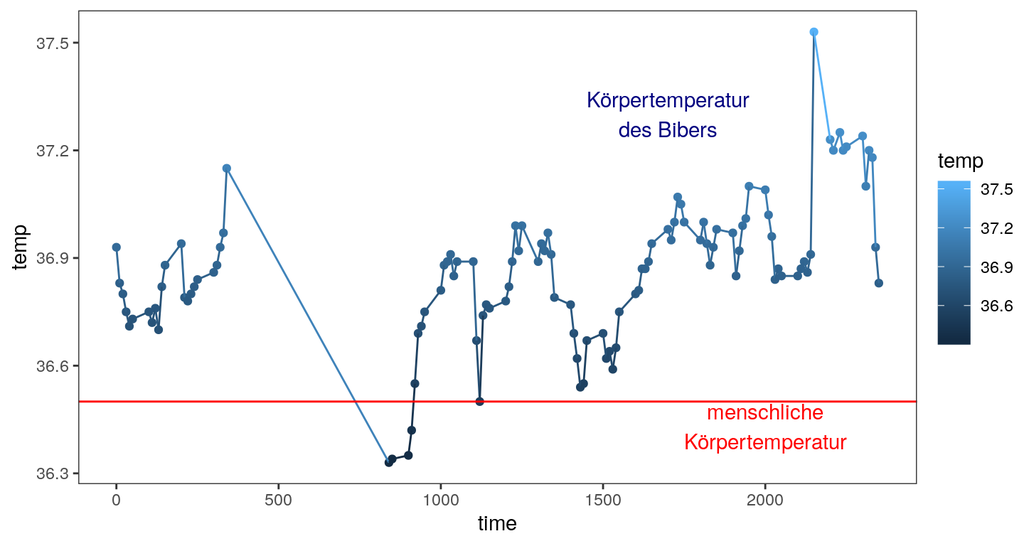